# Markov Chains

Christopher Yau

12/10/2019

# 1 Introduction

In this practical you will learn a number of techniques in R that you will use to simulate simplified games of Monopoly (https://en.wikipedia.org/wiki/Monopoly_(game)). In addition, there are also many tutorials and guides on the Web describing how to produce computer simulations for Monopoly. You are welcome to read and use these examples to inspire your work.

# 2 Getting started in R and Rstudio

## 2.1 R scripts

While entering and running your code at the R command line is effective and simple. This technique has its limitations. Each time you want to execute a set of commands, you have to re-enter them at the command line. Complex commands are potentially subject to typographical errors, necessitating that they be re-entered correctly. Repeating a set of operations requires re-entering the code stream. Fortunately, R and RStudio provide a method to mitigate these issues. R scripts are that solution. A script is simply a text file containing a set of commands and comments. The script can be saved and used later to re-execute the saved commands. The script can also be edited so you can execute a modified version of the commands.

## 2.2 Creating an R script

It is easy to create a new script in RStudio. You can open a new empty script by clicking the New File icon in the upper left of the main RStudio toolbar. This icon looks like a white square with a white plus sign in a green circle. Clicking the icon opens the New File Menu. Click the R Script menu option and the script editor will open with an empty script.

[figure not shown]

Once the new script opens in the Script Editor panel, the script is ready for text entry, and your RStudio session will look like this.

[figure not shown]

Here is an easy example to familiarize you with the Script Editor interface. Type the following code into your new script [later topics will explain the specific code components do].

```
# this is my first R script
# do some things
x = 34
y = 16
z = x + y   # addition
w = y/x     # division
# display the results
x
y
z
w
# change x
x = "some text"
# display the results
x
y
z
w
```

[figure not shown]

There, you now have your first R script. Notice how the editor places a number in front of each line of code. The line numbers can be helpful as you work with your code. Before proceeding on to executing this code, it would be a good idea to learn how to save your script.

## 2.3 Saving an R script

You can save your script by clicking on the Save icon at the top of the Script Editor panel. When you do that, a Save File dialog will open.

[figure not shown]

## 2.4 Executing code in an R script

You can run the code in your R script easily. The Run button in the Script Editor panel toolbar will run either the current line of code or any block of selected code. You can use your First script.R code to gain familiarity with this functionality.

Place the cursor anywhere in line 3 of your script [x = 34]. Now press the Run button in the Script Editor panel toolbar. Three things happen: 1) the code is transferred to the command console, 2) the code is executed, and 3) the cursor moves to the next line in your script. Press the Run button three more times. RStudio executes lines 4, 5, and 6 of your script.

Now you will run a set of code commands all at once. Highlight lines 8, 9, 10, and 11 in the script.

[figure not shown]

Highlighting is accomplished similar to what you may be familiar with in word processor applications. You click your left mouse button and the beginning of the text you want to highlight, you hold the mouse button and drag the cursor to the end of the text and release the button. With those four lines of code highlighted, click the editor Run button. All four lines of code are executed in the command console. That is all it takes to run script code in RStudio.

## 2.5 Comments in an R script [documenting your code]

Before finishing this topic, there is one final concept you should understand. It is always a good idea to place comments in your code. They will help you understand what your code is meant to do. This will become helpful when you reopen code you wrote weeks ago and are trying to work with again. The saying, “Real programmers do not document their code. If it was hard to write, it should be hard to understand” is meant to be a dark joke, not a coding style guide.

[figure not shown]

A comment in R code begins with the # symbol. Your code in First script.R contains several examples of comments. Lines 1, 2, 7, 12, and 14 in the image above are all comment lines. Any line of text that starts with # will be treated as a comment and will be ignored during code execution. Lines 5 and 6 in this image contain comments at the end. All text after the # is treated as a comment and is ignored during execution.

Notice how the RStudio editor shows these comments colored green. The green color helps you focus on the code and not get confused by the comments.

Besides using comments to help make your R code more easily understood, you can use the # symbol to ignore lines of code while you are developing your code stream. Simply place a # in front of any line that you want to ignore. R will treat those lines as comments and ignore them. When you want to include those lines again in the code execution, remove the # symbols and the code is executable again. This technique allows you to change what code you execute without having to retype deleted code.

# 3 Simulating random numbers

There are a number of functions in R that you can use to simulate random numbers according to different probability distributions.

The function `sample` allows you to take a sample of the specified size from the elements of a vector `x` using sampling with or without replacement. You can use `?sample` to read the documentation describing the command.

In the following, we will use the `sample` function to make 10,000 draws from the set of numbers 1, 2, 3 and 4 and display the distribution of the sampled values using a histogram.

First, we define a vector called `x` which contains the numbers 1, 2, 3, and 4. The function `c` allows us to combine these four numbers together into one vector:

```r
  x <- c(1, 2, 3, 4)
```

We now use the function `sample` to pick from those four numbers in `x` 10,000 times. The result, the 10,000 numbers chosen, is store in `out`:

```r
  out <- sample(x, 10000, replace=TRUE)
```

Lets plot a histogram of the values picked:

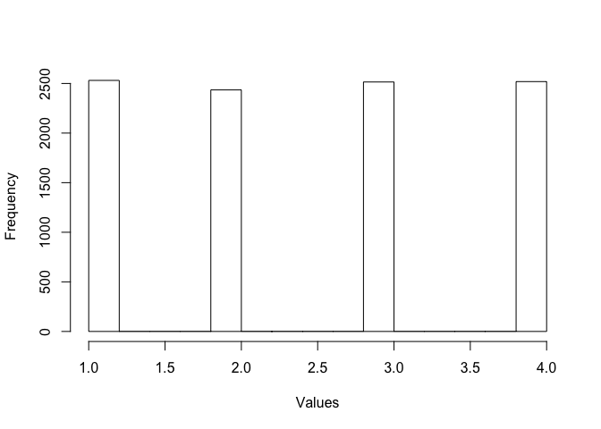

```r
  hist_out <- hist(out, main = '', xlab = 'Values', ylab = 'Frequency')
```

We picked each number with equal probability so the histogram shows each number is equally likely to have been chosen.

**Problem**

> What is the difference in the output `out1` and `out2` in the following piece of code?

```r
  x <- c( 1, 2, 2, 3, 4, 1, 6, 7, 8, 10, 5, 5, 1, 4, 9 )
  out1 <- sample(x, 10, replace=FALSE)
  out2 <- sample(x, 10, replace=TRUE)
```

**Click to expand!**

The option `replace=TRUE` activates sampling with replacement (i.e. the numbers that are picked are put back and can be picked again).

The option `replace=FALSE` activates sampling without replacement (i.e. the numbers that are picked are *not* put back and *cannot* be picked again).

**Problem**

> Use the `sample` or `sample.int` function to simulate values from rolls of an unbiased six-sided die. Show that the distribution of values you obtain is consistent with an unbiased die.

*Hint 1*: Type `?sample.int` in the console to get help on this function.

*Hint 2*: You may find it useful to use the function `table`. Type `?table` in the console to get help on this function.

**Click to expand!**

```r
rolls_from_sample = sample(c(1:6), size=5000, replace=TRUE)
rolls_from_sample.int = sample(6, size=5000, replace=TRUE)

table(rolls_from_sample)
```

```
## rolls_from_sample
##   1   2   3   4   5   6
## 801 861 844 820 867 807
```

```r
table(rolls_from_sample.int)
```

```
## rolls_from_sample.int
##   1   2   3   4   5   6
## 802 842 838 793 885 840
```

Both gives a uniform distribution over the numbers 1-6. The function `sample.int` is a specialised version of `sample` for sampling integers. Many R libraries have specialised versions of more general functions to do specific tasks under certain conditions.

# 4 Markov Chains

Any random process is known to have the *Markov property* (a Markov process) if the probability of going to the next state depends only on the current state and not on the past states. A Markov process is **memoryless property** in that it does not store any property or memory of its past states.

If a Markov process operates within a specific (finite) set of states, it is called a *Markov Chain*.

A Markov Chain is defined by three properties:

1. A state space: a set of values or states in which a process could exist
2. A transition matrix: defines the probability of moving from one state to another state
3. A current state probability distribution: defines the probability of being in any one of the states at the start of the process

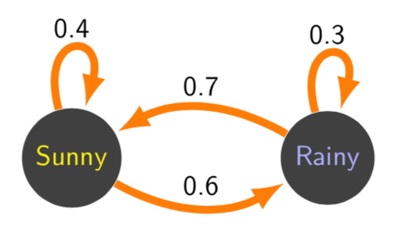

The transition matrix can be written as the following in R:

```r
transitionMatrix = matrix(c(0.4, 0.6, 0.3, 0.7), nrow=2, ncol=2, byrow=TRUE)
print(transitionMatrix)
```

```
##      [,1] [,2]
## [1,]  0.4  0.6
## [2,]  0.3  0.7
```

Suppose I want to simulate a sequence of 30 days and the weather patterns over those days. Assuming that on day 0 it is currently sunny, I can do the following:

```r
state = 1 # initial state - it is [1] sunny or [2] rainy
weather_sequence = rep(0, 30) # vector to store simulated values
for ( day in 1:30 ) { # simulate for 30 days
  pr = transitionMatrix[state, ] # select the row of transition probabilities
  state = sample(c(1, 2), size=1, prob=pr) # sample [1] or [2] based on the probs pr
  weather_sequence[day] = state # store the sampled state
}
print(weather_sequence)
```

```
##  [1] 1 2 2 2 2 1 2 2 2 1 1 2 2 1 2 2 2 2 2 2 1 2 2 2 2 1 2 1 2 1
```

**Problem**

Can you extend this example to a three-state model?

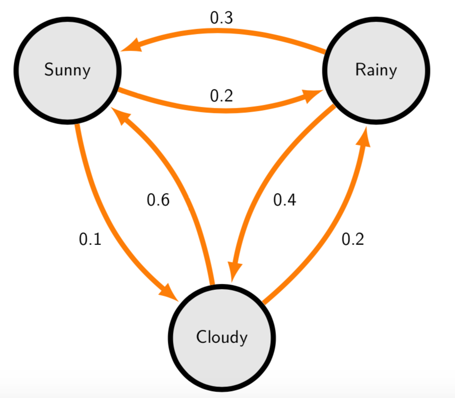

Note, the diagram (intentionally) misses out the self-transitions. You should be able to infer this because the probabilities given would otherwise not add up to one!

**Solution**

**Click to expand!**

Set up a 3x3 transition matrix:

```r
transitionMatrix = matrix(c(0.7, 0.2, 0.1,
                            0.3, 0.3, 0.4,
                            0.6, 0.2, 0.2), nrow=3, ncol=3, byrow=TRUE)
print(transitionMatrix)
```

```
##      [,1] [,2] [,3]
## [1,]  0.7  0.2  0.1
## [2,]  0.3  0.3  0.4
## [3,]  0.6  0.2  0.2
```

Note the ordering of the states is arbitrary but here we have used the convention that State 1 is Sunny, State 2 is Rainy and State 3 is Cloudy which means the probabilities are completed in that order in the transition matrix. We just need to be consistent.

```r
state = 1 # initial state - it is [1] sunny, [2] rainy and [3] cloudy
weather_sequence = rep(0, 30) # vector to store simulated values
for ( day in 1:30 ) { # simulate for 30 days
  pr = transitionMatrix[state, ] # select the row of transition probabilities
  state = sample(c(1, 2, 3), size=1, prob=pr) # sample [1-3] based on the probs pr
  weather_sequence[day] = state # store the sampled state
}
print(weather_sequence)
```

```
##  [1] 1 2 1 1 3 1 2 3 2 2 3 1 3 1 1 1 2 1 3 1 1 1 1 1 1 1 1 2 3 1
```

# 5 A Monopoly simulation

## 5.1 Moving around the board

A Monopoly board has 40 spaces. Players take it in turns to roll two dice and traverse around the board according to the sum of the dice values.

Use the following code example to simulate turns of a single player:

```r
  num_turns <- 100000 # number of turns to take

  current_board_position <- 0 # start on the GO space

  move.size <- rep(0, num_turns)
  positions_visited <- rep(0, num_turns)

  # use a for loop to simulate a number of turns
  for ( turn in 1:num_turns ) {

    # roll two dice
    die.values = sample(c(1:6), 2, replace=TRUE)

    # move player position

    # number of positions to move
    plus.move = sum(die.values)

    # compute new board position
    new_board_position = current_board_position + plus.move

    # update board position (this corrects for the fact the board is circular)
    current_board_position = ( new_board_position %% 40 )

    # store position visited
    positions_visited[turn] <- current_board_position

  }
```

By increasing the number of turns taken, what distribution does the set of simulated board positions converge towards? Show this graphically using the histogram function.

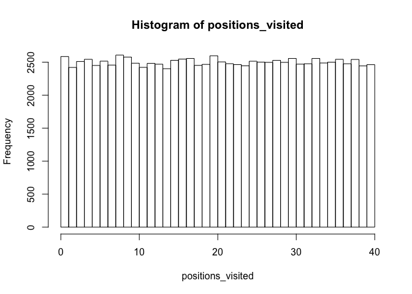

```r
  hist(positions_visited, breaks=seq(0,40,len=41), right=FALSE)
```

## 5.2 Going to Jail

If a player lands on to Go To Jail space they must move immediately to the Jail space. Extend your code to include the possibility of going to jail. Here, assume that once in jail, the player continues as normal on the next turn.

```r
  num_turns <- 100000 # number of turns to take

  current_board_position <- 0 # start on the GO space
  go_to_jail_position = 30 # the go to jail space
  jail_position = 10 # jail space

  move.size <- rep(0, num_turns)
  positions_visited <- rep(0, num_turns)

  # use a for loop to simulate a number of turns
  for ( turn in 1:num_turns ) {

    # roll two dice
    die.values = sample(c(1:6), 2, replace=TRUE)

    # move player position

    # number of positions to move
    plus.move = sum(die.values)

    # compute new board position
    new_board_position = current_board_position + plus.move

    # if land on GO TO JAIL square, then go backwards to the JAIL square
    if ( new_board_position == go_to_jail_position ) {
      new_board_position = jail_position
    }

    # update board position (this corrects for the fact the board is circular)
    current_board_position = ( new_board_position %% 40 )

    # store position visited
    positions_visited[turn] <- current_board_position

  }
```

> What is the distribution of board positions during a long game?

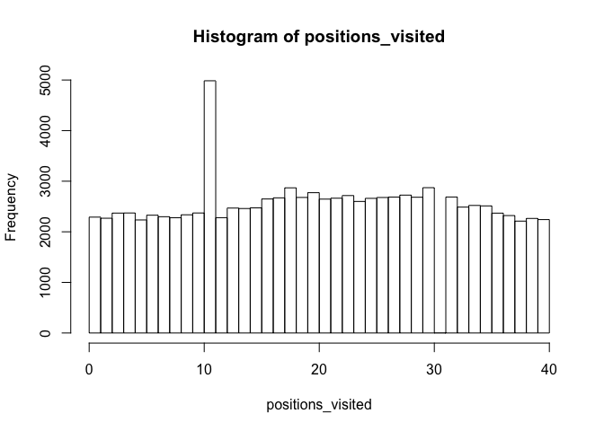

```r
  hist(positions_visited, breaks=seq(0,40,len=41), right=FALSE)
```

> Can you explain this result qualitatively?

You can also go to jail, if you roll three doubles (both dice having the same value) in a row. Update your code to allow for the possibility of going to Jail with three doubles. How does the distribution of board positions change?

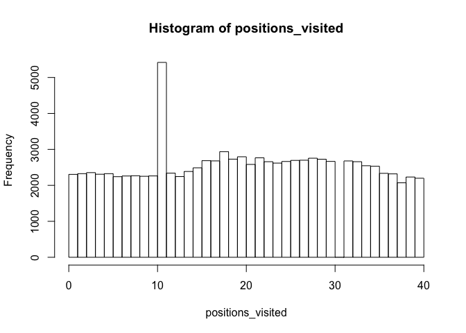

```r
  num_turns <- 100000 # number of turns to take

  current_board_position <- 0 # start on the GO space
  go_to_jail_position = 30 # the go to jail space
  jail_position = 10 # jail space

  move.size <- rep(0, num_turns)
  positions_visited <- rep(0, num_turns)

  # use a for loop to simulate a number of turns
  for ( turn in 1:num_turns ) {

    # set double counter to zero
    double_counter = 0

    # roll (max) three times
    for ( j in 1:3 ){

      # roll two dice
      die.values = sample(c(1:6), 2, replace=TRUE)

      # if we have rolled a double for the third time, we proceed straight to jail
      if ( ( die.values[1] == die.values[2] ) & ( double_counter == 2 ) ) {
        current_board_position = jail_position
        break
      }

      # otherwise

      # move player position

      # number of positions to move
      plus.move = sum(die.values)

      # compute new board position
      new_board_position = current_board_position + plus.move

      # if land on GO TO JAIL square, then go backwards to the JAIL square
      if ( new_board_position == go_to_jail_position ) {
        new_board_position = jail_position
      }

      # update board position (this corrects for the fact the board is circular)
      current_board_position = ( new_board_position %% 40 )

      # break out of loop if we roll a non-double
      if ( die.values[1] != die.values[2] ) {
        break
      } else { # increment double counter
        double_counter = double_counter + 1
      }

    }

    # store final position visited
    positions_visited[turn] <- current_board_position


  }


  hist(positions_visited, breaks=seq(0,40,len=41), right=FALSE)
```

Adding the rolling doubles feature doesn’t seem to change much. We might expect this since rolling three doubles is a very unlikely event!

# 6 Further Exercises

Now consider building a more complex Monopoly simulation by incorporating more complex aspects of the game such as:

- the purchase of properties
- a ledger for each player
- chance and community cards

You will need to think carefully about the simplifying assumptions you will make to make the task achievable. Do not be over-ambitious. For example, you might initially assume that players will not build houses/hotels on properties.

Here are some questions to answer with your simulations:

1. How many turns does it take before all properties are purchased?
2. What are the best properties to buy?
3. How long does it take for a winner to be determined?

For example, the following simple extension of the previous example adds some features to record properties being purchased. This simulation is constructed based on the assumption that a players always buys any free property that land on.

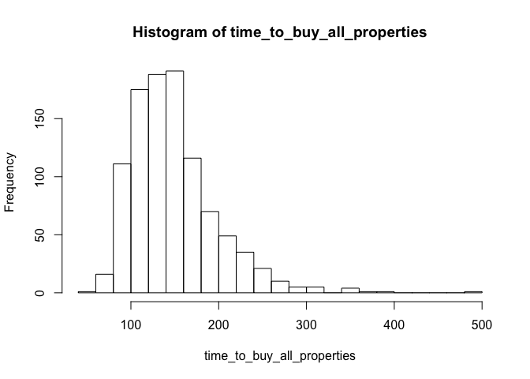

```r
 num_games <- 1000 # number of games to play
num_turns <- 1000 # number of turns to take

current_board_position <- 0 # start on the GO space
go_to_jail_position = 30 # the go to jail space
jail_position = 10 # jail space
properties_that_can_be_bought = c(1, 3, 5, 6, 8, 9, 11, 12, 13, 14, 15, 16, 18, 19, 21, 23, 24, 25, 26, 27, 28, 29, 31, 32, 34, 35, 37, 39) # vector of squares containing properties

time_to_buy_all_properties <- rep(0, num_games) # vector to store number of turns to buy all properties

# simulate multiple games
for ( game in 1:num_games ) {

  move.size <- rep(0, num_turns)
  positions_visited <- rep(0, num_turns)
  positions_purchased <- rep(0, 40)
  properties_bought <- rep(0, num_turns)

  # use a for loop to simulate a number of turns
  for ( turn in 1:num_turns ) {

    # roll two dice
    die.values = sample(c(1:6), 2, replace=TRUE)

    # move player position

    # number of positions to move
    plus.move = sum(die.values)

    # compute new board position
    new_board_position = current_board_position + plus.move

    # if land on GO TO JAIL square, then go backwards to the JAIL square
    if ( new_board_position == go_to_jail_position ) {
      new_board_position = jail_position
    }

    # update board position (this corrects for the fact the board is circular)
    current_board_position = ( new_board_position %% 40 )

    # if we can on a square that can be purchased and which has not been purchased (note R uses 1-indexing for arrays)
    if ( positions_purchased[current_board_position+1] == 0 ) {
      if ( current_board_position %in% properties_that_can_be_bought ) {
        positions_purchased[current_board_position+1] = 1
      }
    }

    # store position visited
    positions_visited[turn] <- current_board_position

    # store number of properties bought
    properties_bought[turn] <- sum(positions_purchased)

    # check if all properties are gone
    if ( properties_bought[turn] == length(properties_that_can_be_bought) ) {
      time_to_buy_all_properties[game] = turn
      break
    }


  }

}

hist(time_to_buy_all_properties, breaks=20)
```